# Bank Client Churn Prediction

2022-11-04

# Introduction

Today’s market is fast-paced and cutthroat. It’s because there are so many different options for where to get the service you need. Service providers face difficulties in adapting to their customers’ shifting behaviors and increasing expectations. Compared to past generations, today’s consumers have much higher expectations and make a wider variety of requests regarding connectivity and novel, individualized approaches. Their education and exposure to new methods put them at the forefront of change. Their buying habits have shifted as a result of their new found knowledge, and they now frequently engage in what is known as “analysis-paralysis,” or excessively deliberating over every detail of the selling and buying process. Therefore, it is imperative that the next generation of service providers innovate creatively in order to meet client needs and increase their value. Companies should value their customers. Shukla (2021) notes that rising levels of competition are placing pressure on businesses to experiment with new marketing strategies in order to keep up with shifting consumer preferences and keep their existing clientele satisfied. Canning) contends that delivering more to everyone is no longer a sustainable sales approach, and that an increasingly competitive market necessitates a plan that prioritizes the most efficient application of marketing resources. In order to keep up with the competition, businesses have turned to technology. The extraction of marketing knowledge and additional direction for business decisions is a common application of data mining techniques. In search of better service or interest rates, customers can quickly and easily migrate from one organization (bank) to another (Jain, et al., 2021). Many businesses have come to believe that acquiring new consumers is a much more challenging and pricey endeavor than maintaining relationships with existing ones. However, another major obstacle is providing quality service to consumers on time and within budget while also having a positive working relationship with them. In order to overcome these obstacles, they must prioritize the wishes of their customers. In particular, they will be focusing on reducing customer turnover. When a company’s customers or subscribers stop using the service or product it provides, this is known as customer churn. To acquire new customers, businesses must utilize their sales and marketing resources in a cycle known as the sales pipeline. Instead of spending money to win over new clients, businesses might save money in the long run by keeping their existing clientele happy. Therefore, it is crucial for any business to have a system in place that can accurately forecast early-stage client turnover. The purpose of this study is to provide a framework for predicting customer attrition in the banking industry by employing a number of Machine Learning methods.

## Customer Churn and Its Effects.

One of the key performance indicators (KPIs) that any successful company must track is the percentage of customer churn among their existing clientele. Many customers leave a business with a high churn rate, which slows growth and has a negative effect on revenue and profits. Companies that have a low churn rate are able to keep their clients. Despite the fact that customer retention rates are not an especially reliable statistic, they are a number that can tell you the truth about how effectively your company is keeping its customers as customers. This is because the number represents the percentage of customers that remain loyal to the company. The percentage of an organization’s overall customer base that ceases making use of the organization’s product or service after a predetermined length of time has elapsed is referred to as the churn rate for that organization. If you know how many customers you had at the beginning of a certain time period and how many customers you lost within that same time period, you will have the information necessary to acquire a clear grasp of your churn rate.

```r
library(vembedr)
embed_youtube("InOB1wXEkC8")
```

[video not shown]

## Purpose of Study

The main objective of this project is construct a model that is able to predict customer churn.

## Significance of Study

Businesses make money by selling goods and services. As a result, the ultimate purpose of churn analysis is to lower churn while increasing revenues. As more clients stay for longer periods of time, sales and profits should rise.Moreover, the expenditure of obtaining a new client is significantly higher than the cost of maintaining an existing one. Even a little increase in customer retention, say 5 percent, can result in a minimum 25 percent increase in revenue. This is because repeat customers are far more valuable to your company, providing an additional 67% to your bottom line. Another reason for this is that loyal customers tend to buy more frequently. Because of this, there will be a lower total number of new customers who need to be serviced, which will result in lower marketing expenses for your business. You don’t need to put in any additional work or spend any further money in order to persuade your current clients that they should keep doing business with you rather than a competitor.

### Benefits of Analyzing Customer Prediction

By using Analytical Methods to Forecast Customer Churn, organizaztions can:

1. Enhance the consumer experience.

An easy-to-avoid mistake like shipping the wrong item is one of the worst ways to lose a customer. Understanding why consumers leave allows you to better understand their objectives, recognize your own flaws, and improve the entire customer experience.

Customer experience, or “CX,” is a customer’s perspective or opinion of their interactions with your company. Your brand’s perception is created throughout the buyer journey, from the first interaction to after-sales assistance, and has a long-term impact on your organization, including your bottom line. Improve your products and services.

You have an opportunity to improve if customers are departing due of particular difficulties with your product, service, or shipping method. Putting these findings into action decreases customer turnover while also improving the overall product or service for future growth.

2. Improve customer loyalty.

Customer retention is the inverse of customer churn. A corporation can keep its consumers while still generating revenue from them. Companies with high customer loyalty can boost the profitability of their existing clients and maximize their lifetime value (LTV). If you sell a service for 1,000 per month and keep the customer for another three months, you will earn an extra $3,000 without spending any money on customer acquisition. The scope and amount vary by business, but the premise of “repeat business = lucrative business” is universal.

3. Increase Profits

Companies generate revenue by peddling their wares to consumers. As a result, the goal of churn analysis is to decrease customer attrition and boost earnings. An uptick in income and ensuing profits can be expected from a rise in average length of stay.

4. Optimize your products and services

You have an opening to enhance your business if clients are defecting due to particular problems with your product or delivery approach. Improvements to the product or service as a whole and a decrease in customer attrition can be achieved by implementing these findings.

# Literature Review

In every industry, the number of service providers has been constantly expanding. Customers today can pick and choose from a wide variety of financial institutions from where to deposit their money. This has made customer retention a major concern for financial institutions. In this research, we offer a strategy for predicting bank customer turnover using machine learning techniques—a subfield of AI. The study encourages more investigation into churn probability by examining customer behavior.

Sayed et al. (2018) investigation was directed based on an assumption that Spark ML bundle has considerably preferred execution and precision over Spark MLlib bundle in managing enormous information. The dataset used in the analysis is comprised of monetary transactions made by bank customers. Based on the data from their transactions, a model was developed using the decision tree algorithm and the two sets of data to predict the likelihood of customer discontent among bank clients. The ML package and its new Data Frame-based APIs have been subjected to granular testing, with the results documenting improved testing performance and forecasting accuracy.This paper proved, that customer churn prediction is attainaible with the right tuning.However, f r this reserch we will not be using any secondary data from a bank and use machine learning algrothms models to evaluate their predictive power. They will be tuned to provide the best model structure so as to improve their prediction ability.

Rahman and Kumar (2020) employed a number of different classifiers, including the KNN, SVM, Decision Tree, and Random Forest methods. In addition, feature selection techniques have been developed to identify the most important traits and validate the efficiency of the system. Kaggle’s churn modeling dataset was used for the experiments. A suitable model with improved accuracy and predictability is identified by comparing the outcomes. Therefore, after oversampling, the Random Forest model outperforms alternatives in terms of predictive power.

Pribil & Polejova (2017) emphasizes on issues of an assumption of the likelihood of a client leaving for rivalry. The expense of gaining another client is generally a few times more than the expense of holding a present client. Agitate demonstrating is a vital asset to help target maintenance activities all the more precisely. A genuine dataset with customer information over which a beat model is produced utilizing strategic relapse and the decision tree is employed in this paper. The CRISP-DM philosophy is tied to the complete procedure. In view of a basic evaluation of the exhibiting technique and its results, ideas are offered for additional work with the models and for enhancing their quality.

Oyeniyi and Adeyemo’s (2015) data mining methodology demonstrates how to anticipate which customers are going to make a fuss. Actual customer data from a legitimate Nigerian bank was used in the analysis. WEKA, a data-digging programming instrument for learning exploration, was used to clean, pre-prepare, and analyze the raw data. In the clustering phase, we used simple K-Means, and in the standardization phase, we used JRip, a calculation based on standards. Results showed that the approaches used can determine patterns in client behavior, allowing banks to identify potential churners and develop ways to retain them.

## Data Description

```
Feature Description:
    Customer ID - ID of a client.
    Credit Score - It is the score which determines the creditworthiness of a client.
    Country - The country of the client.
    Gender - gender of client.
    Age - age of client.
    Tenure - how many years he/she is having bank acc in Bank.
    Balance - Account Balance.
    Products Number - Number of Product from Bank.
    Credit Card - Does the customer own a credit card of that Bank.
    Active Member - Is he/she is active Member of bank ?
    Estimated Salary - Income of the Customer.
    Churn - Churn (Loss of existing customers) of the Bank.
```

### Libraries

```r
# Library for data manipulation
library(tidyverse)
# Library for machine learning models
library(tidymodels)
# Library for recipe function step_up sample for unbalanced data
library(themis)
# Library for tuning functions
library(stacks)
#Library for random forest model
library(ranger)
#Library for boosted tree model
library(xgboost)
#Library for logistic regression model
library(glmnet)
library(kknn)
```

# Data preprocessing

### Data cleaning

The data was relatively tidy, it is still crucial to look for any missing values and also ensure that the allocated variable class types were accurate so as to ensure a smooth analysis process.

```r
data <- read.csv("Bank Customer Churn Prediction.csv")
str(data)
```

```
## 'data.frame':    10000 obs. of  12 variables:
##  $ customer_id     : int  15634602 15647311 15619304 15701354 15737888 15574012 15592531 15656148 15792365 15592389 ...
##  $ credit_score    : int  619 608 502 699 850 645 822 376 501 684 ...
##  $ country         : chr  "France" "Spain" "France" "France" ...
##  $ gender          : chr  "Female" "Female" "Female" "Female" ...
##  $ age             : int  42 41 42 39 43 44 50 29 44 27 ...
##  $ tenure          : int  2 1 8 1 2 8 7 4 4 2 ...
##  $ balance         : num  0 83808 159661 0 125511 ...
##  $ products_number : int  1 1 3 2 1 2 2 4 2 1 ...
##  $ credit_card     : int  1 0 1 0 1 1 1 1 0 1 ...
##  $ active_member   : int  1 1 0 0 1 0 1 0 1 1 ...
##  $ estimated_salary: num  101349 112543 113932 93827 79084 ...
##  $ churn           : int  1 0 1 0 0 1 0 1 0 0 ...
```

```r
data %>% skimr::skim() %>%
  skimr::yank("numeric") %>% as_tibble() %>%
  select(-p25, -p75) %>% knitr::kable()
```

| skim_variable | n_missing | complete_rate | mean | sd | p0 | p50 | p100 | hist |
| --- | --- | --- | --- | --- | --- | --- | --- | --- |
| customer_id | 0 | 1 | 1.569094e+07 | 7.193619e+04 | 15565701.00 | 15690738.00 | 15815690.0 | ▇▇▇▇▇ |
| credit_score | 0 | 1 | 6.505288e+02 | 9.665330e+01 | 350.00 | 652.00 | 850.0 | ▁▃▇▇▃ |
| age | 0 | 1 | 3.892180e+01 | 1.048781e+01 | 18.00 | 37.00 | 92.0 | ▅▇▂▁▁ |
| tenure | 0 | 1 | 5.012800e+00 | 2.892174e+00 | 0.00 | 5.00 | 10.0 | ▇▆▆▆▅ |
| balance | 0 | 1 | 7.648589e+04 | 6.239741e+04 | 0.00 | 97198.54 | 250898.1 | ▇▃▇▂▁ |
| products_number | 0 | 1 | 1.530200e+00 | 5.816544e-01 | 1.00 | 1.00 | 4.0 | ▇▇▁▁▁ |
| credit_card | 0 | 1 | 7.055000e-01 | 4.558405e-01 | 0.00 | 1.00 | 1.0 | ▃▁▁▁▇ |
| active_member | 0 | 1 | 5.151000e-01 | 4.997969e-01 | 0.00 | 1.00 | 1.0 | ▇▁▁▁▇ |
| estimated_salary | 0 | 1 | 1.000902e+05 | 5.751049e+04 | 11.58 | 100193.91 | 199992.5 | ▇▇▇▇▇ |
| churn | 0 | 1 | 2.037000e-01 | 4.027686e-01 | 0.00 | 0.00 | 1.0 | ▇▁▁▁▂ |

```r
data %>% skimr::skim() %>% skimr::yank("character")
```

**Variable type: character**

| skim_variable | n_missing | complete_rate | min | max | empty | n_unique | whitespace |
| --- | --- | --- | --- | --- | --- | --- | --- |
| country | 0 | 1 | 5 | 7 | 0 | 3 | 0 |
| gender | 0 | 1 | 4 | 6 | 0 | 2 | 0 |

There are 10000 observations with 0 missing values. Some variables despite being factors shown as numeric values e.g. churn, credit_card etc, lets convert them into factors. Also lets remove id column as we would not need it.

```r
data %>%
  select(-customer_id) %>%
  mutate(products_number = as.factor(products_number)) %>%
  mutate(credit_card = as.factor(credit_card)) %>%
  mutate(active_member = as.factor(active_member)) %>%
  mutate(churn = as.factor(churn)) ->  data
```

### Data spliting

Let’s split data on train and test sets. With proportion 80% train data, 20% test data. The train set will be used in modelling while the test set will be used to test the accuracy of the models.

```r
set.seed(420)
data_split <- data %>%
  initial_split(prop = 0.8, strata = "churn")

train_data <- training(data_split)
test_data <- testing(data_split)

dim(train_data)
```

```
## [1] 7999   11
```

```r
dim(test_data)
```

```
## [1] 2001   11
```

We have 7999 observations in our train dataset and 2001 observations in the test set

# Exploratory Data Analysis

### Distribution of Gender

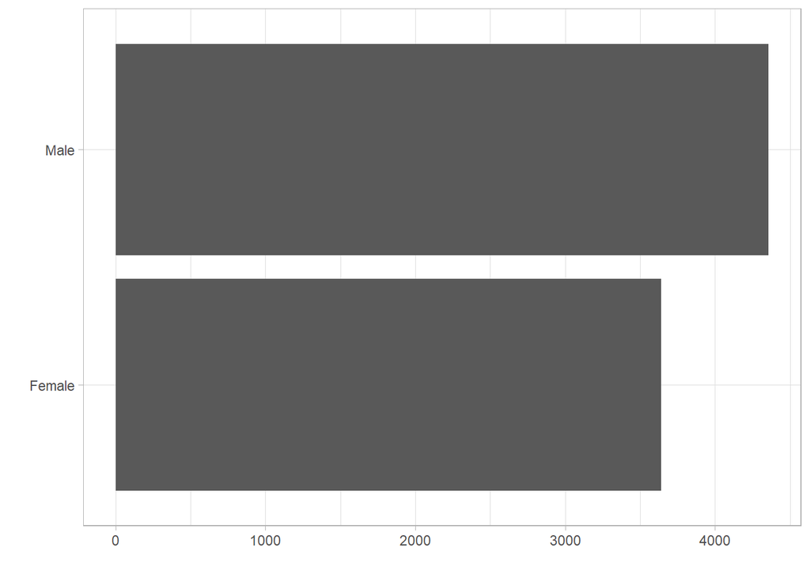

```r
train_data %>%
  count(gender) %>%
  ggplot()+
  aes(gender, n)+
  geom_col()+
  labs(x = "", y  ="")+
  theme_light()+
  coord_flip()
```

It is noted that the data records the largest number of its customers are male rather than female. Historically, female business owners have had more trouble or paid more to get bank loans. These issues may be caused by supply-side discrimination or by the profitability of businesses held by men and women differently. The fact that more men than women use banks, particularly for deposit accounts, may be due to the difficulty in obtaining bank loans.

### Distribution of Gender by country

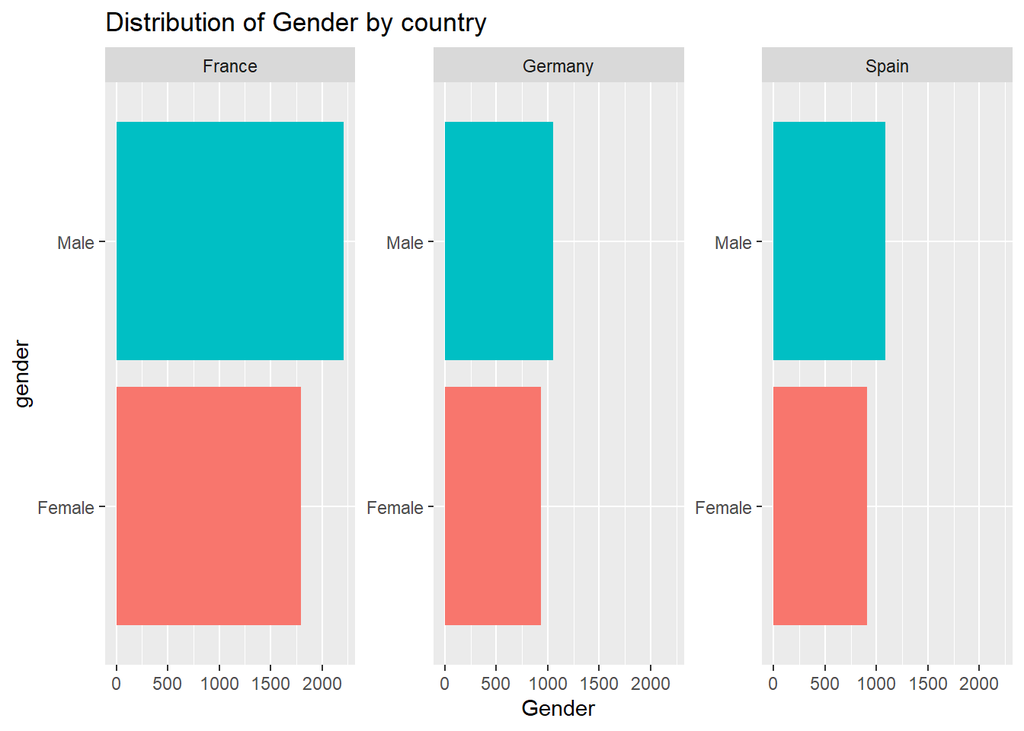

```r
train_data%>%
  group_by(gender, country) %>%
  count() %>%
  ggplot(aes(gender, n, fill = gender)) +
  geom_col(show.legend = FALSE) +
  facet_wrap(~country, scales = "free_y") +
  coord_flip() +
  labs(
    title = "Distribution of Gender by country",
    y = "Gender"
  )
```

Across the three countries recorded in this data,the higher proportion of customers are male. It seems that the historical tendency of female business owners having more trouble to get bank loans exists across all the countries as depicted in France,German and Spain.

### How many contries are there?

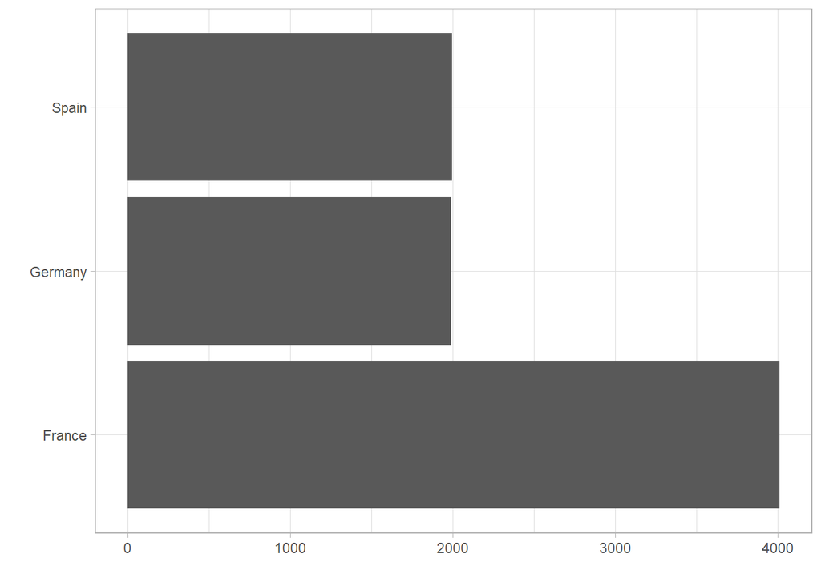

```r
train_data %>%
  count(country) %>%
  ggplot()+
  aes(country, n)+
  geom_col()+
  labs(x = "", y  ="")+
  theme_light()+
  coord_flip()
```

There 3 countries, namely, Spain, Germany and France. Based on the above plot, France has the highest count compared to Spain and Germany.

### Distribution of balance

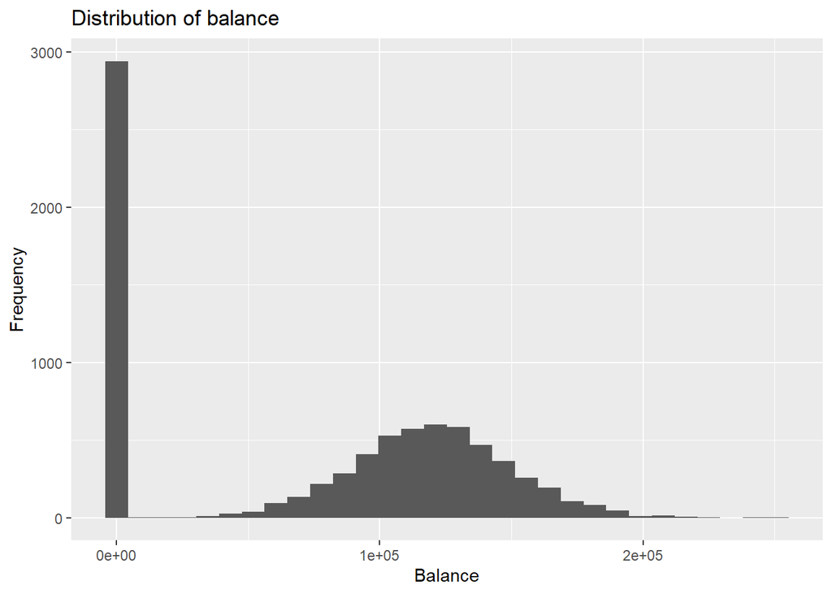

```r
ggplot(train_data, aes(x=balance)) +
  geom_histogram()+ggtitle("Distribution of balance")+xlab("Balance")+ylab("Frequency")
```

### Distribution of balance by gender

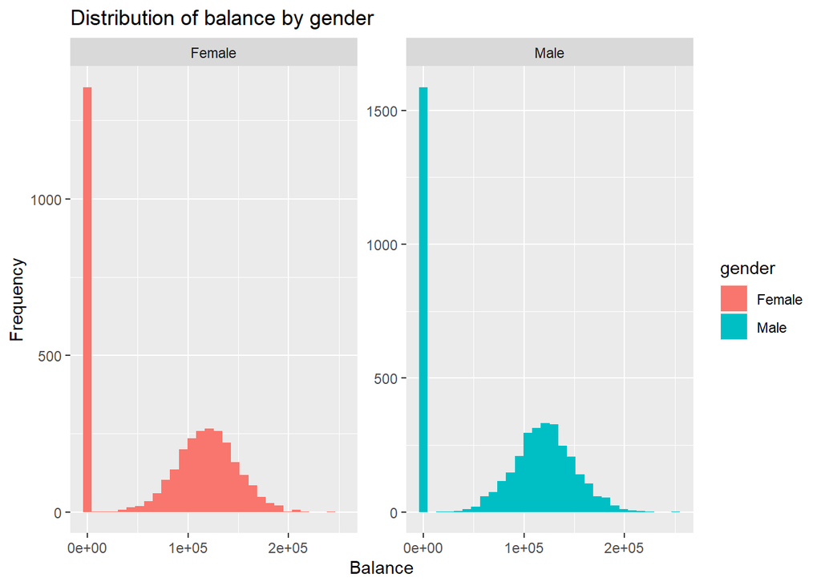

```r
ggplot(train_data, aes(x=balance,fill=gender)) +
  geom_histogram()+ggtitle("Distribution of balance by gender")+xlab("Balance")+ylab("Frequency")+
  facet_wrap(~gender, scales = "free_y")
```

### Distribution of balance by country

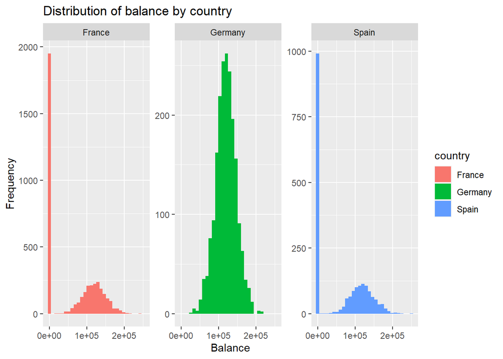

```r
ggplot(train_data, aes(x=balance,fill=country)) +
  geom_histogram()+ggtitle("Distribution of balance by country")+xlab("Balance")+ylab("Frequency")+
  facet_wrap(~country, scales = "free_y")
```

### Distribution of balance per product type

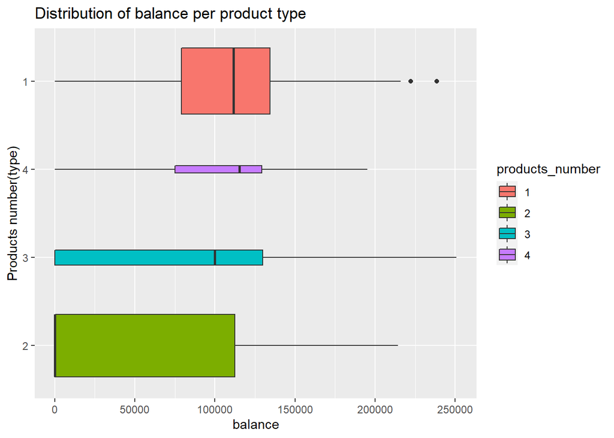

```r
ggplot(train_data, aes(reorder(products_number, balance), balance,fill=products_number)) +
  geom_boxplot(varwidth = TRUE) +
  coord_flip() +
  labs(
    title = "Distribution of balance per product type",
    x = "Products number(type)"
  )
```

### Distribution of balance per gender

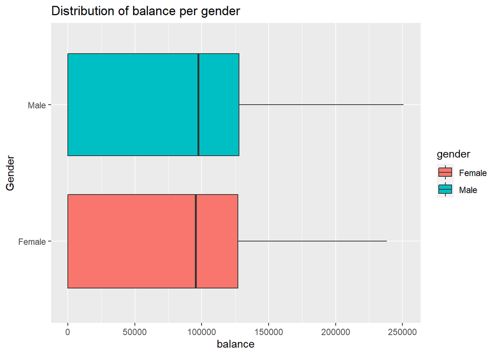

```r
ggplot(train_data, aes(reorder(gender, balance), balance,fill=gender)) +
  geom_boxplot(varwidth = TRUE) +
  coord_flip() +
  labs(
    title = "Distribution of balance per gender",
    x = "Gender"
  )
```

### Distribution of balance per churn

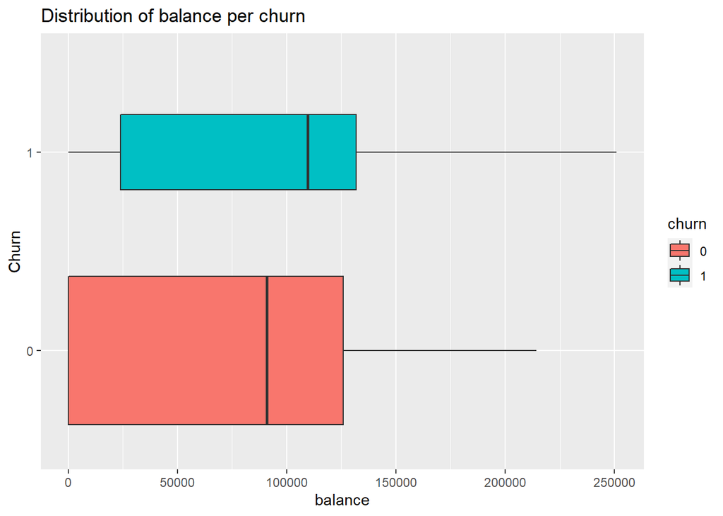

```r
ggplot(train_data, aes(reorder(churn, balance), balance,fill=churn)) +
  geom_boxplot(varwidth = TRUE) +
  coord_flip() +
  labs(
    title = "Distribution of balance per churn",
    x = "Churn"
  )
```

### Distribution of Estimated salary

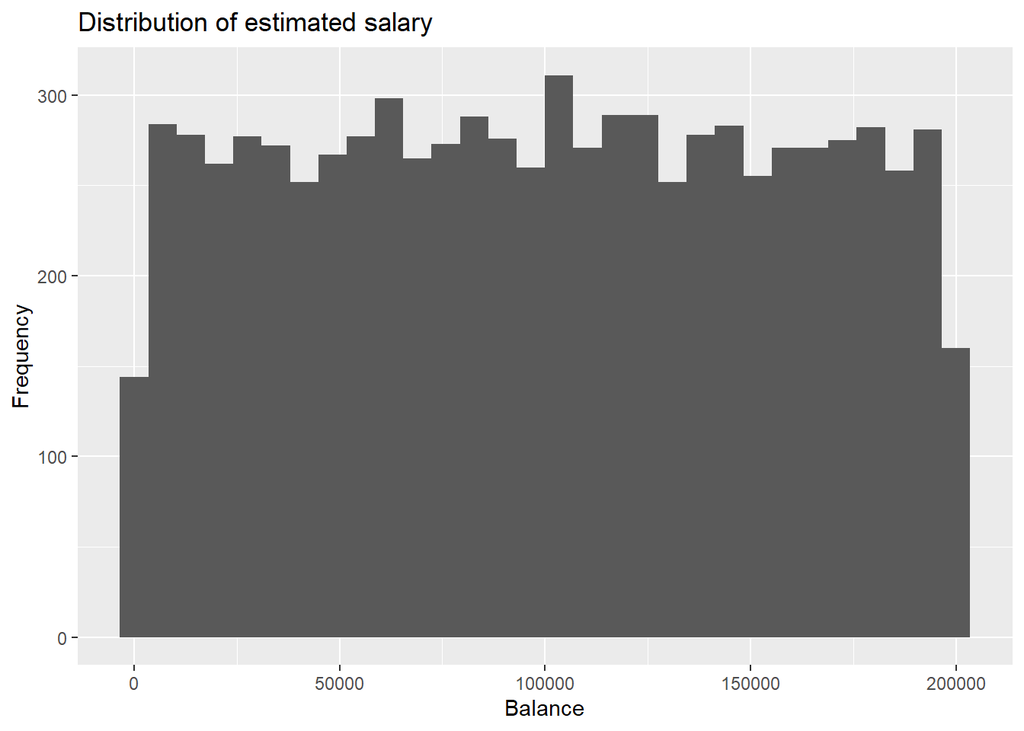

```r
ggplot(train_data, aes(x=estimated_salary)) +
  geom_histogram()+ggtitle("Distribution of estimated salary")+xlab("Balance")+ylab("Frequency")
```

### Distribution of estimated salary by gender

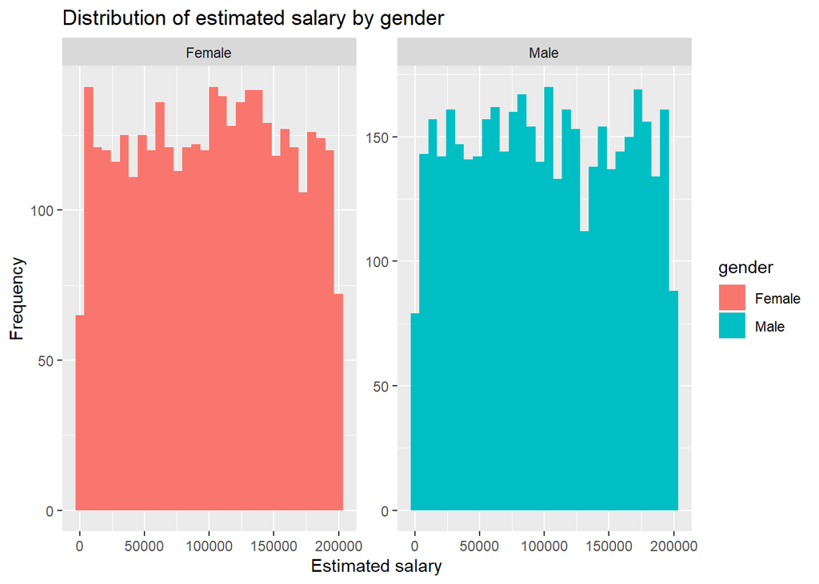

```r
ggplot(train_data, aes(x=estimated_salary,fill=gender)) +
  geom_histogram()+ggtitle("Distribution of estimated salary by gender")+xlab("Estimated salary")+ylab("Frequency")+
  facet_wrap(~gender, scales = "free_y")
```

### Distribution of estimated salary by country

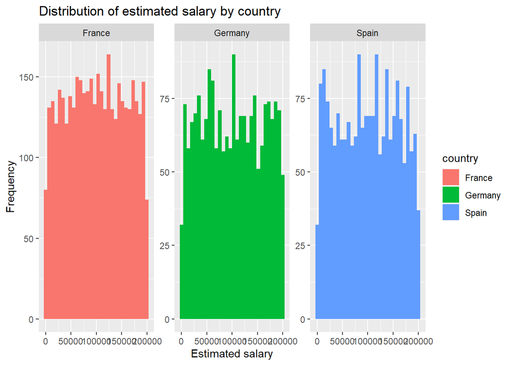

```r
ggplot(train_data, aes(x=estimated_salary,fill=country)) +
  geom_histogram()+ggtitle("Distribution of estimated salary by country")+xlab("Estimated salary")+ylab("Frequency")+
  facet_wrap(~country, scales = "free_y")
```